# 506326047_stats102a_HW2

Abhijeet Rao

2024-02-04

# Question 1.

## Creating the Simulated Data.

Below is the code block that shows how I created the simulated data. First I used the `runif()` function to produce 1200 random values. 1200 because we have 100 rows of 5 quizzes and 7 quizzes so $100\cdot(5 + 7) = 1200$. Then we reshape that into a matrix with 12 columns. Finally we combine the matrices with sequentially generated `UIDs`.

```r
set.seed(506326047) ## set the seed to UID

## Create a character vector containing the names of homeworks and quizzes
names <- paste0("Homework_", 1:5)
names <- append(names, paste0("Quiz_", 1:7))

## Create the gradebook_matrix with 1200 observations and reshape it to a matrix.
gradebook_matrix <- matrix(runif(n = 1200, min = 0, max = 100), ncol = length(names), byrow = TRUE)

## Rename the columns
colnames(gradebook_matrix) <- names

## Create the gradebook dataframe with the UID column and the gradebook_matrix.
gradebook <- data.frame(UID = 123456789 + (1:100), gradebook_matrix)
```

## Creating Missing Values.

To generate the missing values we use the `sample()` function to give us 12 indices of rows between 0 and 100 and then change those values to `NA`.

```r
## create the list of random rows we will replace with NA
for (i in sample(100, 12)) {
  gradebook$Homework_4[i] <- NA
}
sum(is.na(gradebook$Homework_4))
```

```
## [1] 12
```

```r
for (i in sample(100, 12)) {
  gradebook$Quiz_4[i] <- NA
}
sum(is.na(gradebook$Quiz_4))
```

```
## [1] 12
```

```r
gradebook <- as_tibble(gradebook)
```

## The `messy_impute()` function.

### Algorithm

I will speak about the algorithm from the `center = "mean"` initially since the `center = "median"` is essentially the exact same, just use the `median()` function instead. Throughout all these calculations for means we are ignoring `NA` values by using the `na.rm = TRUE` argument.

The key part of this function’s algorithm is the following line:

```r
na_matrix <- which(is.na(input_tibble), arr.ind = TRUE)
```

This line allows stores the indices of the `NA` values in a matrix with the row and column index of the `NA` value.

#### Row-By-Row

Here is the algorithm for the row-by-row/student `NA` impute;

1. If `margin = 1` then do the row-by-row replacement of `NA` values which is the following;
2. For each row in the `na_matrix` first check if the row is a Homework assignment or Quiz Assignment just by seeing if the column of the `NA` value we are checking is between columns 2-6 or 7-13.
3. To make the code more readable, store the row as a tibble into the `placeholder_row` variable.
4. Remove the names on the row so we can actually perform the mean function using the `unlist(..., use.names=FALSE)`
5. If we are replacing a Homework then use only the homework row by slicing indices 2-6 of the row. If we are replacing a Quiz then use the quiz row by slicing indices 7-13 of the row.
6. Calculate the mean of the row and input it into the cell that we were looking at with the `NA` value.
7. Repeat this for each `NA` value.
8. Return the tibble.

Next, here is the algorithm for the column/assignment `NA` impute:

side-note: this one was much simpler as column operations are very easy to do with tibbles whereas rows are a bit tougher to work with.

1. If `margin = 2` then do the column replacement of `NA` values which is the following;
2. For each column in the `na_matrix` take the mean of the entire column and input it into the missing value cell.
3. Repeat for each `NA` value.
4. Return the tibble

#### Test Case

Here I showcase the student with UID 123456797 and the imputation of their `NA` scores for the Homework 4 assignments.

```r
gradebook[8, ]
```

```
## # A tibble: 1 × 13
##         UID Homework_1 Homework_2 Homework_3 Homework_4 Homework_5 Quiz_1 Quiz_2
##       <dbl>      <dbl>      <dbl>      <dbl>      <dbl>      <dbl>  <dbl>  <dbl>
## 1 123456797       45.4      0.648       64.1         NA       11.3   21.6   24.5
## # ℹ 5 more variables: Quiz_3 <dbl>, Quiz_4 <dbl>, Quiz_5 <dbl>, Quiz_6 <dbl>,
## #   Quiz_7 <dbl>
```

```r
messy_impute(gradebook, "mean", 1)[8, ]
```

```
## # A tibble: 1 × 13
##         UID Homework_1 Homework_2 Homework_3 Homework_4 Homework_5 Quiz_1 Quiz_2
##       <dbl>      <dbl>      <dbl>      <dbl>      <dbl>      <dbl>  <dbl>  <dbl>
## 1 123456797       45.4      0.648       64.1       30.4       11.3   21.6   24.5
## # ℹ 5 more variables: Quiz_3 <dbl>, Quiz_4 <dbl>, Quiz_5 <dbl>, Quiz_6 <dbl>,
## #   Quiz_7 <dbl>
```

```r
messy_impute(gradebook, "median", 2)[8, ]
```

```
## # A tibble: 1 × 13
##         UID Homework_1 Homework_2 Homework_3 Homework_4 Homework_5 Quiz_1 Quiz_2
##       <dbl>      <dbl>      <dbl>      <dbl>      <dbl>      <dbl>  <dbl>  <dbl>
## 1 123456797       45.4      0.648       64.1       44.8       11.3   21.6   24.5
## # ℹ 5 more variables: Quiz_3 <dbl>, Quiz_4 <dbl>, Quiz_5 <dbl>, Quiz_6 <dbl>,
## #   Quiz_7 <dbl>
```

```r
messy_impute(gradebook, "mean", 1, trim = 0.25)[8, ]
```

```
## # A tibble: 1 × 13
##         UID Homework_1 Homework_2 Homework_3 Homework_4 Homework_5 Quiz_1 Quiz_2
##       <dbl>      <dbl>      <dbl>      <dbl>      <dbl>      <dbl>  <dbl>  <dbl>
## 1 123456797       45.4      0.648       64.1       28.4       11.3   21.6   24.5
## # ℹ 5 more variables: Quiz_3 <dbl>, Quiz_4 <dbl>, Quiz_5 <dbl>, Quiz_6 <dbl>,
## #   Quiz_7 <dbl>
```

## Conversion into tidy data.

To convert the `gradebook` data set into tidy data we use the `pivot_longer()` function. Additionally make sure we didn’t lose any `NA` values through our test cases before hand.

```r
gradebook_tidy <- gradebook %>% pivot_longer(
  cols = !UID,
  names_to = "Assignments",
  values_to = "Marks"
)
gradebook_tidy
```

```
## # A tibble: 1,200 × 3
##          UID Assignments Marks
##        <dbl> <chr>       <dbl>
##  1 123456790 Homework_1  89.9
##  2 123456790 Homework_2  67.2
##  3 123456790 Homework_3  64.1
##  4 123456790 Homework_4  69.7
##  5 123456790 Homework_5  42.5
##  6 123456790 Quiz_1      45.5
##  7 123456790 Quiz_2      26.0
##  8 123456790 Quiz_3       6.70
##  9 123456790 Quiz_4      32.1
## 10 123456790 Quiz_5      55.4
## # ℹ 1,190 more rows
```

## The `tidy_impute()` function.

### Algorithm

The error handling is the same as `messy_impute()`. For the algorithm below I will again follow the `center = 'mean'` function with both `margin = 1` and `margin = 2`.

The first step in both algorithms is the finding where the `NAs` are and this is done using the following line: `tidy_na <- which(is.na(input_tibble), arr.ind=TRUE)`

Additionally, since we might encounter input tibbles with differing column names I included the following line which changes the column names and changes them back later:

```r
original_colnames <- colnames(input_tibble)
colnames(input_tibble) <- c("UID", "Assignments", "Marks")
...
colnames(input_tibble) <- original_colnames
return(input_tibble)
```

#### Row-by-row algorithm (`margin = 1`)

1. Take the `NA` value indices from the `tidy_na` database.
2. Find the `NA` in the input tibble and take the `UID` of the student.
3. Find all the assignments of the student.
4. If the index of the `NA` is in the first 5 then it is a homework assignment and we must only mean the homeworks.
5. Otherwise it is a quiz and we mean the quizzes.
6. Replace the `NA` value with the mean calculated using the `mean()` function.

#### Column algorithm (`margin = 2`)

1. Take the `NA` value indices from the `tidy_na` database.
2. Take the assignment type of that `NA` value.
3. Use the `filter()` function to find all the values of that assignment type.
4. Use the `mean()` function to get the mean.
5. Replace the `NA` value with the mean.

# Question 2

### Ideas

The first thing that came to mind was about categorical data that splits values and names. Similar to the data-set we just made tidy.

1. Consumption of a good by some demographic.
   1. Context – Say you want to measure the consumption of goods by specific demographics.
   2. Variables – The demographic itself is one variable, then we would have a column for each good we are tracking.
   3. Observation – The observations would be the amount of each good consumed.
2. Time-based tracking of the distance of an object.
   1. Context – Suppose you are tracking an objects distance from you throughout the days of the year.
   2. Variables – The object id itself, Each day of the year would be its own column
   3. Observation – Each observation would be the distance from you to the object you are tracking.
3. Seafood Haul
   1. Context – Suppose you are a fishing company tracking the hauls from your fishing boats.
   2. Variables – Your boats you want to track. Each type of fish would be its own column.
   3. Observations – The amount of the type of fish caught in each

## Actual Data Sets

I was able to find three different data sets that seem to have non-tidy data.

### 1. Global Alcohol Consumption.

I was able to find this data set through the “rfordatascience” github, specifically the “TidyTuesday” repo that contains thousands of datasets. You can find the link [here](https://github.com/rfordatascience/tidytuesday).

**Citation**:

Mona Chalabi, *Global Alcohol Consumption*, 13th August 2014. FiveThirtyEight [publisher], github.com/rfordatascience/tidytuesday/tree/master/data/2018. 4th February 2024

#### Reading and Tidying the Dataset.

```r
alcohol <- read_csv("datasets/alcohol_global.csv")
alcohol
```

```
## # A tibble: 193 × 5
##    country    beer_servings spirit_servings wine_servings total_litres_of_pure…¹
##    <chr>              <dbl>           <dbl>         <dbl>                  <dbl>
##  1 Afghanist…             0               0             0                    0
##  2 Albania               89             132            54                    4.9
##  3 Algeria               25               0            14                    0.7
##  4 Andorra              245             138           312                   12.4
##  5 Angola               217              57            45                    5.9
##  6 Antigua &…           102             128            45                    4.9
##  7 Argentina            193              25           221                    8.3
##  8 Armenia               21             179            11                    3.8
##  9 Australia            261              72           212                   10.4
## 10 Austria              279              75           191                    9.7
## # ℹ 183 more rows
## # ℹ abbreviated name: ¹total_litres_of_pure_alcohol
```

```r
alcohol_tidy <- alcohol %>% pivot_longer(
  cols = c("beer_servings", "spirit_servings", "wine_servings"),
  names_to = "serving_type",
  values_to = "amount of servings"
)
alcohol_tidy$serving_type <- substr(alcohol_tidy$serving_type, 1, nchar(alcohol_tidy$serving_type) - 9)
alcohol_tidy
```

```
## # A tibble: 579 × 4
##    country     total_litres_of_pure_alcohol serving_type `amount of servings`
##    <chr>                              <dbl> <chr>                       <dbl>
##  1 Afghanistan                          0   beer                            0
##  2 Afghanistan                          0   spirit                          0
##  3 Afghanistan                          0   wine                            0
##  4 Albania                              4.9 beer                           89
##  5 Albania                              4.9 spirit                        132
##  6 Albania                              4.9 wine                           54
##  7 Algeria                              0.7 beer                           25
##  8 Algeria                              0.7 spirit                          0
##  9 Algeria                              0.7 wine                           14
## 10 Andorra                             12.4 beer                          245
## # ℹ 569 more rows
```

### 2. Total Wealth in Great Britain.

I found this next dataset through the Office for National Statistics(ONS) a department of the government of the United Kingdom. They released this dataset looking at the total wealth of individuals. This method is essentially similar to Idea #2. Instead of tracking the distance of an object, we are tracking the wealth of people through time.

**Citation**:

Office for National Statistics United Kingdom, *Total Wealth in Great Britain*, 7th January 2022, www.ons.gov.uk/peoplepopulationandcommunity/personalandhouseholdfinances/incomeandwealth/datasets/totalwealthwealthingreatbritain, 4th February 2024.

Here is an image of what the data looked like before converting it into a CSV :

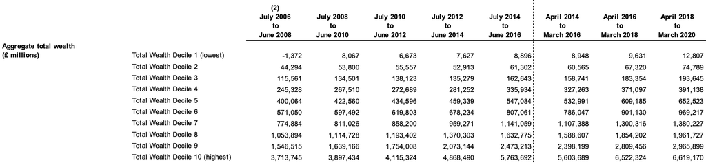

Snapshot of Wealth in Great Britain Dataset.

#### Reading and Tidying the Dataset.

We run the code just as before and get:

```r
total_aggregate <- read_csv("datasets/UK_wealth/csv_files/total_aggregate_clean.csv")

total_aggregate
```

```
## # A tibble: 10 × 9
##    `Wealth Decile`                 July 2006 to June 20…¹ July 2008 to June 20…²
##    <chr>                                            <dbl>                  <dbl>
##  1 Total Wealth Decile 1 (lowest)                   -1372                   8067
##  2 Total Wealth Decile 2                            44294                  53800
##  3 Total Wealth Decile 3                           115561                 134501
##  4 Total Wealth Decile 4                           245328                 267510
##  5 Total Wealth Decile 5                           400064                 422560
##  6 Total Wealth Decile 6                           571050                 597492
##  7 Total Wealth Decile 7                           774884                 811026
##  8 Total Wealth Decile 8                          1053894                1114728
##  9 Total Wealth Decile 9                          1546515                1639166
## 10 Total Wealth Decile 10 (highes…                3713745                3897434
## # ℹ abbreviated names: ¹`July 2006 to June 2008\n`, ²`July 2008 to June 2010\n`
## # ℹ 6 more variables: `July 2010 to June 2012\n` <dbl>,
## #   `July 2012 to June 2014\n` <dbl>, `July 2014 to June 2016\n` <dbl>,
## #   `April 2014 to March 2016` <dbl>, `April 2016 to March 2018` <dbl>,
## #   `April 2018 to March 2020` <dbl>
```

Once again we can simply tidy the data using the `pivot_longer()` functions by sending the names of columns to `Time Range` and the values to `GBP_Millions`.

```r
total_aggregate_tidy <- total_aggregate %>% pivot_longer(
  cols = !`Wealth Decile`,
  names_to = "Time Range",
  values_to = "GBP Millions"
)
total_aggregate_tidy
```

```
## # A tibble: 80 × 3
##    `Wealth Decile`                `Time Range`               `GBP Millions`
##    <chr>                          <chr>                               <dbl>
##  1 Total Wealth Decile 1 (lowest) "July 2006 to June 2008\n"          -1372
##  2 Total Wealth Decile 1 (lowest) "July 2008 to June 2010\n"           8067
##  3 Total Wealth Decile 1 (lowest) "July 2010 to June 2012\n"           6673
##  4 Total Wealth Decile 1 (lowest) "July 2012 to June 2014\n"           7627
##  5 Total Wealth Decile 1 (lowest) "July 2014 to June 2016\n"           8896
##  6 Total Wealth Decile 1 (lowest) "April 2014 to March 2016"           8948
##  7 Total Wealth Decile 1 (lowest) "April 2016 to March 2018"           9631
##  8 Total Wealth Decile 1 (lowest) "April 2018 to March 2020"          12807
##  9 Total Wealth Decile 2          "July 2006 to June 2008\n"          44294
## 10 Total Wealth Decile 2          "July 2008 to June 2010\n"          53800
## # ℹ 70 more rows
```

### 3. United States Average Tuition Cost.

This is another data set from the TidyTuesday collection. This dataset looks at the Average Tuition in every State from 2004 to 2016.

**Citation**:

Online MBA Page, *Average Tuition in the United States*, 3rd April 2018, onlinembapage.com/average-tuition-and-educational-attainment-in-the-united-states/, Online MBA Page[publisher], Tom Mock[consolidater]. 4th February 2024.

#### Reading and Tidying the Dataset.

```r
us_average_tuition <- read_csv("datasets/us_avg_tuition.csv")

us_average_tuition
```

```
## # A tibble: 50 × 13
##    State   `2004-05` `2005-06` `2006-07` `2007-08` `2008-09` `2009-10` `2010-11`
##    <chr>       <dbl>     <dbl>     <dbl>     <dbl>     <dbl>     <dbl>     <dbl>
##  1 Alabama     5683.     5841.     5754.     6008.     6475.     7189.     8071.
##  2 Alaska      4328.     4633.     4918.     5070.     5075.     5455.     5759.
##  3 Arizona     5138.     5416.     5481.     5682.     6058.     7263.     8840.
##  4 Arkans…     5772.     6082.     6232.     6415.     6416.     6627.     6901.
##  5 Califo…     5286.     5528.     5335.     5672.     5898.     7259.     8194.
##  6 Colora…     4704.     5407.     5596.     6227      6284.     6948.     7748.
##  7 Connec…     7984.     8249.     8368.     8678.     8721.     9371.     9827.
##  8 Delawa…     8353.     8611.     8682.     8946.     8995.     9987.    10534.
##  9 Florida     3848.     3924.     3888.     3879.     4150      4783.     5511.
## 10 Georgia     4298.     4492.     4584.     4790.     4831.     5550.     6428.
## # ℹ 40 more rows
## # ℹ 5 more variables: `2011-12` <dbl>, `2012-13` <dbl>, `2013-14` <dbl>,
## #   `2014-15` <dbl>, `2015-16` <dbl>
```

Once again to convert this data set into a tidy dataset we use the `pivot_longer()` function below:

```r
us_average_tuition_tidy <- us_average_tuition %>% pivot_longer(
  cols = !State,
  names_to = "Year",
  values_to = "Cost"
)
us_average_tuition_tidy
```

```
## # A tibble: 600 × 3
##    State   Year     Cost
##    <chr>   <chr>   <dbl>
##  1 Alabama 2004-05 5683.
##  2 Alabama 2005-06 5841.
##  3 Alabama 2006-07 5754.
##  4 Alabama 2007-08 6008.
##  5 Alabama 2008-09 6475.
##  6 Alabama 2009-10 7189.
##  7 Alabama 2010-11 8071.
##  8 Alabama 2011-12 8452.
##  9 Alabama 2012-13 9098.
## 10 Alabama 2013-14 9359.
## # ℹ 590 more rows
```

### Final Thoughts.

It seems that the most common type of messy data, is data that is tracked throughout time periods. Both the 2nd and 3rd datasets are examples of this type of messy data. While it may seem intuitive, this style does not conform to the tidy convention. However, this type of messy data seems relatively easy to convert into tidy data via the `pivot_longer()` function.